# Project Python Foundations: FoodHub Data Analysis

### **Question 10**: What is the mean order delivery time? [1 mark]

```python
# Write the code to find mean order delivery time
print(f"Mean order delivery time is : {df['delivery_time'].mean().round(2)} minutes")
```

```
Mean order delivery time is : 24.16 minutes
```

#### Observations:

Mean order delivery time is 24.16 minutes

### **Question 11:** The company has decided to give 20% discount vouchers to the top 3 most frequent customers. Find the IDs of these customers and the number of orders they placed. [1 mark]

```python
# Give 20% discount vouchers to the top 3 most frequent customers
df['customer_id'].value_counts().sort_values(ascending=False).head(3)
```

| customer_id | count |
| --- | --- |
| 52832 | 13 |
| 47440 | 10 |
| 83287 | 9 |

**dtype:** int64

#### Observations:

Customer ids of the top 3 most frequent customers are 52832, 47440 and 83287

### **Question 12**: Perform a multivariate analysis to explore relationships between the important variables in the dataset. (It is a good idea to explore relations between numerical variables as well as relations between numerical and categorical variables) [10 marks]

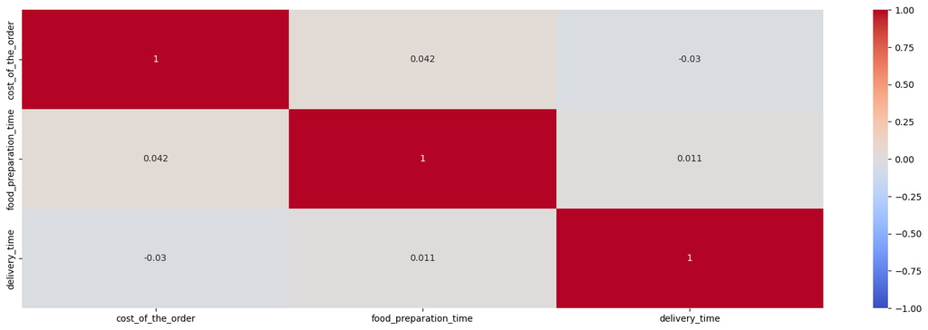

```python
# Check for correlation among numerical variables
num_var = ['cost_of_the_order','food_preparation_time','delivery_time']
corr = df[num_var].corr()
# Plot the heatmap
plt.figure(figsize=(20, 6))
# add the different color to the below heatmap
sns.heatmap(corr, annot=True, vmin=-1, vmax=1, cmap='coolwarm')
plt.show()
```

Observations:

Plotting heatmap to get some idea on the realtionshipo between numerical data in the dataframe. With the result, it is evident that there is not much positive or negative correlation between the numerical data(cost_of_the_order, food_preparation_time and delivery_time) columns.

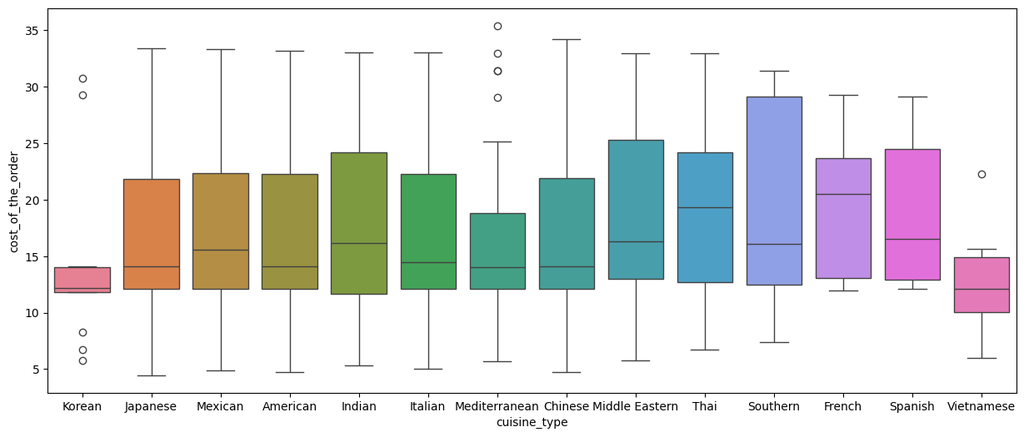

```python
#  Plot the relation between cost_of_the_order and cuisine_type
plt.figure(figsize=(15, 6))
sns.boxplot(x='cuisine_type', y='cost_of_the_order', data=df, hue='cuisine_type')
plt.show()
```

Observations:

- Most of the cusine_types, data is right skewed except Thai and French.
- There are outliers in Korean, Mediterranean and Vietnamese.
- Median cost of French is higher than all other cuisines.
- Median cost of Vietnamese is lower than all other cuisines.

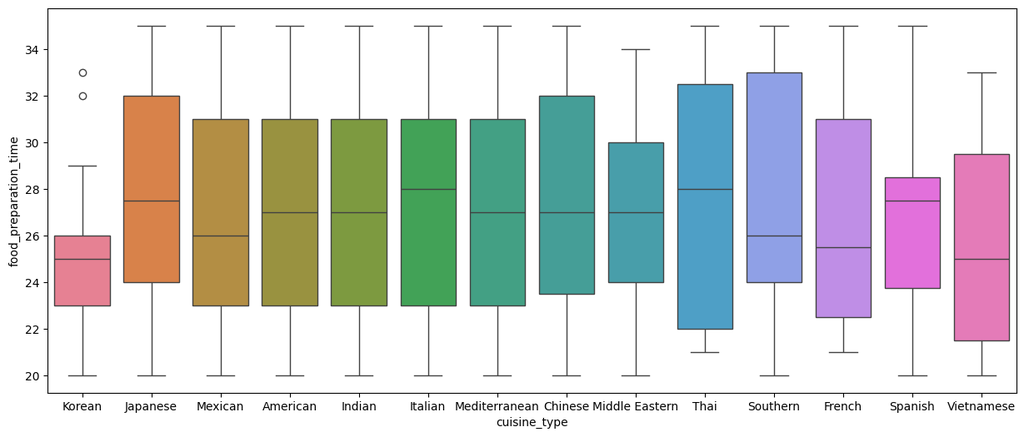

```python
#  Plot the relation between food_preparation_time and cuisine_type
plt.figure(figsize=(15, 6))
sns.boxplot(x='cuisine_type', y='food_preparation_time', data=df, hue='cuisine_type')
plt.show()
```

Observations:

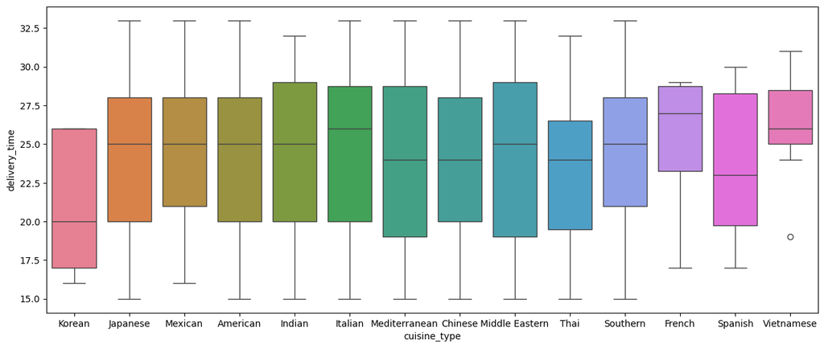

```python
#  Plot the relation between delivery_time and cuisine_type
plt.figure(figsize=(15, 6))
sns.boxplot(x='cuisine_type', y='delivery_time', data=df, hue='cuisine_type')
plt.show()
```

Observations:

- There are outliers on Vietnamese cuisine.
- Most of the cusines data is uniformly distributed.
- 75% of the orders of any cuisine are delivered within 30 mins

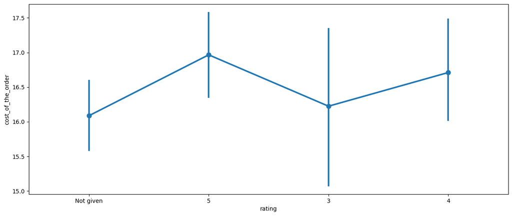

```python
#  Plot the relation between cost_of_the_order and rating
plt.figure(figsize=(15, 6))
sns.pointplot(x='rating', y='cost_of_the_order', data=df)
plt.show()
```

Observations:

- There is no direct relation between cost of the order and rating.

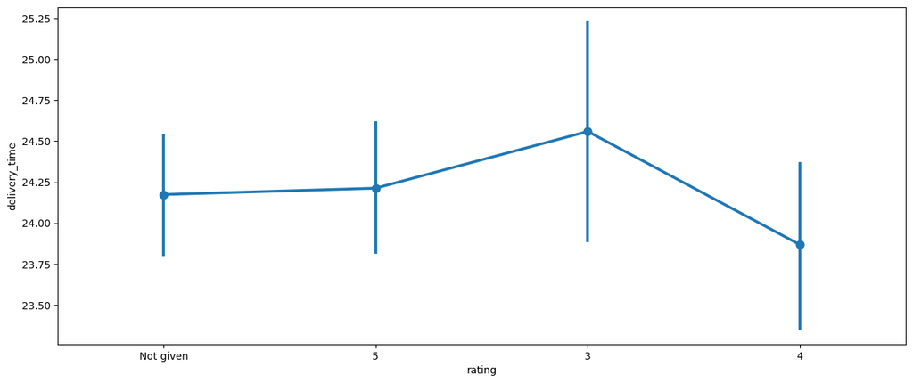

```python
#  Plot the relation between delivery_time and rating

plt.figure(figsize=(15, 6))
sns.pointplot(x='rating', y='delivery_time', data=df)
plt.show()
```

Observations:

- There is no direct relation between delivery time and and rating.

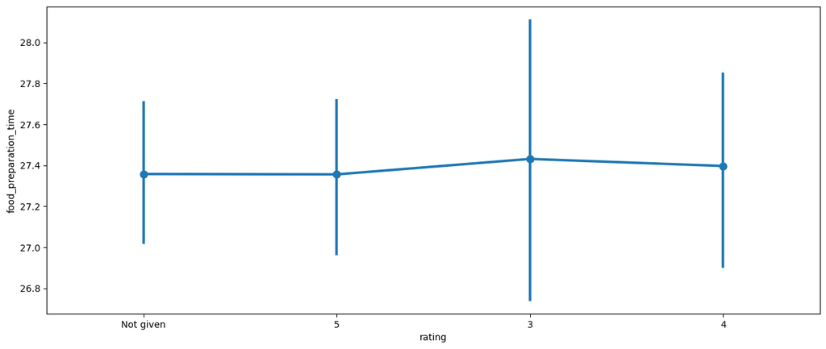

```python
#  Plot the relation between food_preparation_time and rating
plt.figure(figsize=(15, 6))
sns.pointplot(x='rating', y='food_preparation_time', data=df)
plt.show()
```

Observations:

- There is no direct relation between food preparation time and rating.

[figure not shown]

```python
#  Plot the relation between day_of_the_week and rating

plt.figure(figsize=(15, 6))
sns.pointplot(x='rating', y='day_of_the_week', data=df)
plt.show()
```

Observations:

- There is no direct relation between day of the week and rating.

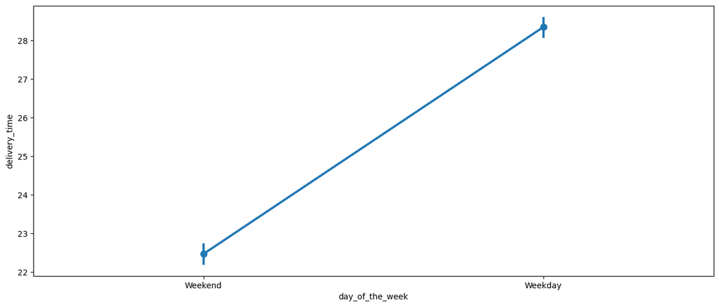

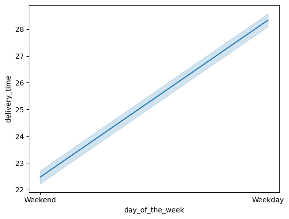

```python
#  Plot the relation between day_of_the_week and delivery_time

plt.figure(figsize=(15, 6))
sns.pointplot(x='day_of_the_week', y='delivery_time', data=df)
plt.show()
sns.lineplot(x='day_of_the_week', y='delivery_time', data=df)
plt.show()
```

Observations:

- Here is the interesting behavior, Delivery time is more on the weekdays than on the weekends.

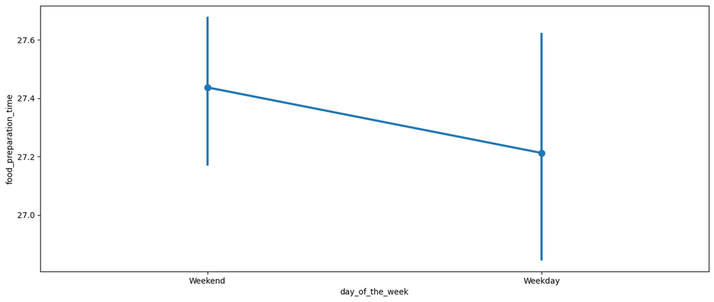

```python
#  Write the code to plot the relation between food_preparation_time and rating

plt.figure(figsize=(15, 6))
sns.pointplot(x='day_of_the_week', y='food_preparation_time', data=df)
plt.show()
```

Observations:

- Food preparation time is more on the weekends than on the weekdays.

### **Question 13:** The company wants to provide a promotional offer in the advertisement of the restaurants. The condition to get the offer is that the restaurants must have a rating count of more than 50 and the average rating should be greater than 4. Find the restaurants fulfilling the criteria to get the promotional offer. [3 marks]

```python
# remove the records containing rating as not given from the dataframe
orders_rated = df[df['rating'] != 'Not given'].copy()

# convert rating column to integer
orders_rated['rating'] = orders_rated['rating'].astype(int)

# Grouping by restaurant name and counting the number of ratings for each restaurant
rating_counts = orders_rated.groupby('restaurant_name')['rating'].count().reset_index()

# Filtering restaurants with more than 50 ratings
filtered_rest_by_count = rating_counts[rating_counts['rating'] > 50]
print(f"Restaurants having ratings > 50 are: \n\n{filtered_rest_by_count}")

# Merging with the original dataframe to get ratings for each restaurant
merged_rest_with_counts = orders_rated[orders_rated['restaurant_name'].isin(filtered_rest_by_count['restaurant_name'])]

# Selecting only the restaurant name and rating
restaurant_ratings = merged_rest_with_counts[['restaurant_name', 'rating']]
print(f"\nNo, of total orders for the filtered restaurants: {restaurant_ratings.shape[0]}")

# find the restaurants with mean rating > 4
mean_ratings = restaurant_ratings.groupby('restaurant_name')['rating'].mean().reset_index()
mean_ratings_gt_4 = mean_ratings[mean_ratings['rating'] > 4].sort_values(by='rating', ascending=False)
print(f"\n\nNo, of restaurants with rating count> 50 and mean rating > 4 are: \n\n{mean_ratings_gt_4}")
```

```
Restaurants having ratings > 50 are:

               restaurant_name  rating
16   Blue Ribbon Fried Chicken      64
17           Blue Ribbon Sushi      73
117                Shake Shack     133
132          The Meatball Shop      84

No, of total orders for the filtered restaurants: 354


No, of restaurants with rating count> 50 and mean rating > 4 are:

             restaurant_name  rating
3          The Meatball Shop   4.512
0  Blue Ribbon Fried Chicken   4.328
2                Shake Shack   4.278
1          Blue Ribbon Sushi   4.219
```

#### Observations:

Based on the conditions provided, the company has to provide a promotional offer on the below restaurants

The Meatball Shop  
Blue Ribbon Fried Chicken  
Shake Shack  
Blue Ribbon Sushi

### **Question 14:** The company charges the restaurant 25% on the orders having cost greater than 20 dollars and 15% on the orders having cost greater than 5 dollars. Find the net revenue generated by the company across all orders. [3 marks]

```python
# Find the orders with cost_of_the_order > $20
orders_cost_gt_20 = df[df['cost_of_the_order'] > 20]

# Find the ordrs with cost with > $5 and < $20
orders_cost_gt_5 = df[(df['cost_of_the_order'] > 5) & (df['cost_of_the_order'] <= 20)]

# Calculate the net revenue generated by the company
gen_revenue = (orders_cost_gt_20['cost_of_the_order'] * 0.25).sum() + (orders_cost_gt_5['cost_of_the_order'] * 0.15).sum()

# Print the net revenue generated by the company and round it to 2 decimal places
print(f"The revenue generated by the company across all orders is ${round(gen_revenue,2)}")
```

```
The revenue generated by the company across all orders is $6166.3
```

#### Observations:

By applying the charges based on the cost of the orders, the total revenue the company generated with the given percentages is 6166.3 dollars

### **Question 15:** The company wants to analyze the total time required to deliver the food. What percentage of orders take more than 60 minutes to get delivered from the time the order is placed? (The food has to be prepared and then delivered.) [2 marks]

```python
# Add the food_preparation_time and delivery_time of each order into a new column
df['total_time'] = df['food_preparation_time'] + df['delivery_time']

# Find the percentage of the orders taking more than 60 mins total time
percentage_gt_60 = (df[df['total_time'] > 60].shape[0]/df.shape[0])*100

# Round it to 2 decimal places
print(f"The percentage of the orders taking more than 60 mins to get delivered from the time the order is placed is: {round(percentage_gt_60,2)}%")
```

```
The percentage of the orders taking more than 60 mins to get delivered from the time the order is placed is: 10.54%
```

#### Observations:

10.54% of the orders are taking more than 60 mins for food delivery.

### **Question 16:** The company wants to analyze the delivery time of the orders on weekdays and weekends. How does the mean delivery time vary during weekdays and weekends? [2 marks]

```python
# Mean delivery time on weekdays
df.groupby('day_of_the_week')['delivery_time'].mean()
```

| day_of_the_week | delivery_time |
| --- | --- |
| Weekday | 28.340 |
| Weekend | 22.470 |

**dtype:** float64

#### Observations:

Mean Delivery time over the weekday is 28.34 minutes Mean delivery tiem over the weedend is 22.47 minutes

### Recommendations:

- Consider the high delivery times during the weekdays while estimating the total time to deliver for any order.
- Provide incentives to the custumers to give rating after each visit.
- As the orders are more over the weekend, arrange more delivery persons during the weekend.